# Assignment5

Mustafa Yıldız

23 Kasım 2018

# Examine The Full Car Sales Data

**Data Structure**

Let’s have a quick look to the data structure.

```r
tmp<-tempfile(fileext=".rds")
download.file("https://github.com/MEF-BDA503/pj18-yildizmust/blob/master/car_data_aggregate.rds?raw=true",destfile=tmp,mode='wb')
car_data_aggregate <- readRDS(tmp)
cda=car_data_aggregate
str(cda)
```

```
## Classes 'tbl_df', 'tbl' and 'data.frame':    1490 obs. of  12 variables:
##  $ brand_name : chr  "ALFA ROMEO" "ASTON MARTIN" "AUDI" "BENTLEY" ...
##  $ auto_dom   : num  0 0 0 0 0 0 0 0 0 632 ...
##  $ auto_imp   : num  13 2 350 0 158 ...
##  $ auto_total : num  13 2 350 0 158 ...
##  $ comm_dom   : num  0 0 0 0 0 0 0 0 0 789 ...
##  $ comm_imp   : num  0 0 0 0 0 197 319 0 0 199 ...
##  $ comm_total : num  0 0 0 0 0 197 319 0 0 988 ...
##  $ total_dom  : num  0 0 0 0 0 ...
##  $ total_imp  : num  13 2 350 0 158 331 1460 9 3 256 ...
##  $ total_total: num  13 2 350 0 158 ...
##  $ year       : num  2018 2018 2018 2018 2018 ...
##  $ month      : num  9 9 9 9 9 9 9 9 9 9 ...
```

```r
head(cda)
```

```
##     brand_name auto_dom auto_imp auto_total comm_dom comm_imp comm_total
## 1   ALFA ROMEO        0       13         13        0        0          0
## 2 ASTON MARTIN        0        2          2        0        0          0
## 3         AUDI        0      350        350        0        0          0
## 4      BENTLEY        0        0          0        0        0          0
## 5          BMW        0      158        158        0        0          0
## 6      CITROEN        0      134        134        0      197        197
##   total_dom total_imp total_total year month
## 1         0        13          13 2018     9
## 2         0         2           2 2018     9
## 3         0       350         350 2018     9
## 4         0         0           0 2018     9
## 5         0       158         158 2018     9
## 6         0       331         331 2018     9
```

```r
tail(cda)
```

```
##      brand_name auto_dom auto_imp auto_total comm_dom comm_imp comm_total
## 1485  SSANGYONG        0       19         19        0        3          3
## 1486       TATA        0        0          0        0        9          9
## 1487     TOYOTA     1298      149       1447        0       34         34
## 1488 VOLKSWAGEN        0     2792       2792        0     1736       1736
## 1489      VOLVO        0      187        187        0        0          0
## 1490    TOPLAM:     7375    15983      23358     4815     4540       9355
##      total_dom total_imp total_total year month
## 1485         0        22          22 2016     1
## 1486         0         9           9 2016     1
## 1487      1298       183        1481 2016     1
## 1488         0      4528        4528 2016     1
## 1489         0       187         187 2016     1
## 1490     12190     20523       32713 2016     1
```

**Data Cleaning**

There are some rows that have “TOPLAM:”, we should remove these rows. Secondly, assume that zero value total-total cells are not needed, can not be observd, so we should also remove these total_total rows that have zero values.

```r
cda<-cda[!(cda$brand_name=="TOPLAM:"),]
cda<-cda[!(cda$total_total==0),]
```

**Max Sales**

Let’s find the max total sales of cars in the selected period.

```r
head(cda[order(cda$total_total,decreasing = TRUE),],10)
```

```
##      brand_name auto_dom auto_imp auto_total comm_dom comm_imp comm_total
## 957     RENAULT    11492     6998      18490        0     2588       2588
## 419     RENAULT    11420     4820      16240        0     2814       2814
## 394        FIAT     7947      401       8348     8821     1023       9844
## 966  VOLKSWAGEN        0    14539      14539        0     3543       3543
## 395        FORD      706     3840       4546    11642      676      12318
## 930        FIAT     7522      422       7944     7680     1074       8754
## 427  VOLKSWAGEN        0    13003      13003        0     3290       3290
## 931        FORD     1938     3263       5201     9894      685      10579
## 1014 VOLKSWAGEN        0    10587      10587        0     3772       3772
## 464     RENAULT     7692     4283      11975        0     2009       2009
##      total_dom total_imp total_total year month
## 957      11492      9586       21078 2016    12
## 419      11420      7634       19054 2017    12
## 394      16768      1424       18192 2017    12
## 966          0     18082       18082 2016    12
## 395      12348      4516       16864 2017    12
## 930      15202      1496       16698 2016    12
## 427          0     16293       16293 2017    12
## 931      11832      3948       15780 2016    12
## 1014         0     14359       14359 2016    11
## 464       7692      6292       13984 2017    11
```

```r
head(cda[order(cda$total_total,decreasing = FALSE),],10)
```

```
##       brand_name auto_dom auto_imp auto_total comm_dom comm_imp comm_total
## 44  ASTON MARTIN        0        1          1        0        0          0
## 46       BENTLEY        0        1          1        0        0          0
## 65         LEXUS        0        1          1        0        0          0
## 86  ASTON MARTIN        0        1          1        0        0          0
## 128 ASTON MARTIN        0        1          1        0        0          0
## 130      BENTLEY        0        1          1        0        0          0
## 135      FERRARI        0        1          1        0        0          0
## 171 ASTON MARTIN        0        1          1        0        0          0
## 173      BENTLEY        0        1          1        0        0          0
## 178      FERRARI        0        1          1        0        0          0
##     total_dom total_imp total_total year month
## 44          0         1           1 2018     8
## 46          0         1           1 2018     8
## 65          0         1           1 2018     8
## 86          0         1           1 2018     7
## 128         0         1           1 2018     6
## 130         0         1           1 2018     6
## 135         0         1           1 2018     6
## 171         0         1           1 2018     5
## 173         0         1           1 2018     5
## 178         0         1           1 2018     5
```

At the first ten max sales rows, Renault and Wolkswagen have three rows each, and fiat and ford have two rows each.

**Is There any Seasonality in the Car Sales Data**

Let’s calculate the average total car sales for each month of selected years.

```r
for (i in 1:12) as.numeric(print.table(mean(cda$total_total[cda$month == i])))
```

```
## [1] 893.7565
## [1] 1241.5
## [1] 1972.449
## [1] 1776.298
## [1] 1917.742
## [1] 1834.886
## [1] 1613.033
## [1] 1474.694
## [1] 1297.43
## [1] 2063.688
## [1] 2755.16
## [1] 3392.098
```

There is a significant seasonality at the last months (November, December) of years.

**Plot the Total Car Sales**

By using ggplot2, plot a column diagram.Firstly, convert last to columns($year and $month) into date format.

```r
cda$date1=paste0(cda$month,"/",1,"/",cda$year)
cda$date1=as.Date(cda$date1, format='%m/%d/%Y')
```

Then plot the Total Car Sales graph.

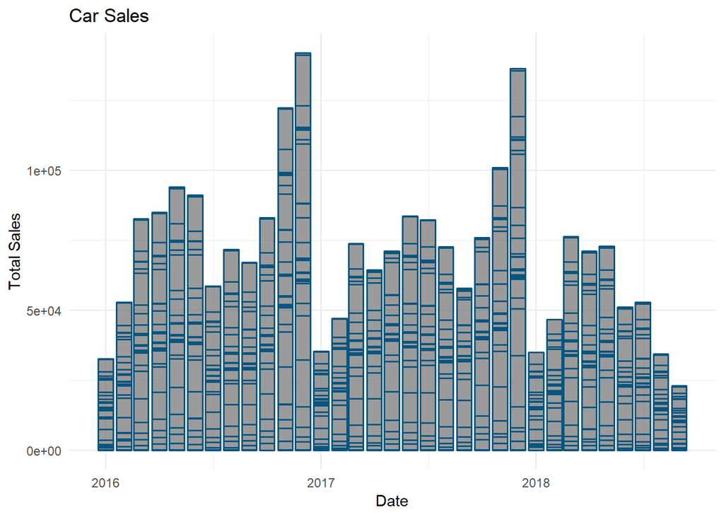

```r
library(ggplot2)
g1= ggplot(data = cda) +
  geom_col(aes(x = date1, y = cda$total_total),
            color = "#09557f",
            alpha = 0.6,
            size = 0.6) +
  labs(x = "Date",
       y = "Total Sales",
       title = "Car Sales") +
  theme_minimal()
g1
```